# PyQtGraph backend

`registration1d.plot` draws with Matplotlib. For use inside a Qt application (PyQt6 / PySide6), `registration1d.plotqt` provides the same helpers on top of [PyQtGraph](https://www.pyqtgraph.org) (MIT licence), which renders through Qt's scene graph and stays interactive — pan, zoom, hover — with thousands of curves. It is an optional dependency:

```
pip install "registration1d[qt]" PyQt6      # or PySide6
```

The functions mirror the Matplotlib ones (`plot_curves`, `plot_warps`, `plot_displacement_fields`, `plot_registration`) and `RegistrationResult.plot(backend='pyqtgraph')` is a shortcut. Two design points matter for embedding:

- every function accepts an existing PyQtGraph `PlotItem` / `PlotWidget` through the `plot=` argument (or a `GraphicsLayoutWidget` through `win=`) and draws into it, so an application keeps ownership of its widgets; with no target a stand-alone widget is created and returned;
- nothing starts a Qt event loop. Call `plotqt.app().exec()` for a stand-alone window, or let the host application run its loop.

This notebook runs *off-screen* (no display is needed) and shows the PyQtGraph output as PNG images rendered with `plotqt.to_image`, next to the corresponding Matplotlib figures for comparison.

```python
import os
os.environ['QT_QPA_PLATFORM'] = 'offscreen'      # render without a display (must precede the Qt import)
import sys, os
sys.path.insert(0, os.path.abspath('../src'))   # so that this notebook finds registration1d without installation
import numpy as np
from matplotlib import pyplot as plt
import registration1d as reg1d
import util                                      # notebooks/util.py: example datasets and permutation tests
print('registration1d version:', reg1d.__version__)
from registration1d import plotqt
from IPython.display import Image, display
import pyqtgraph as pg
print('pyqtgraph', pg.__version__, '| Qt binding:', pg.Qt.QT_LIB)
```

```
registration1d version: 0.0.2
pyqtgraph 0.14.0 | Qt binding: PyQt6
```

```python
dataset = util.Dorn2012()
speed   = dataset.group
yi      = reg1d.register_linear(dataset.y, n=101).y
colors  = ['k','b','g','r']
labels  = [f'Speed = {i}' for i in range(4)]
result  = reg1d.register_srsf(yi, max_iter=5)
```

### 1. Three-panel registration summary — PyQtGraph versus Matplotlib

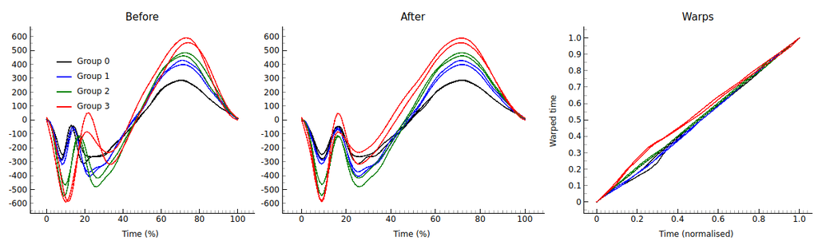

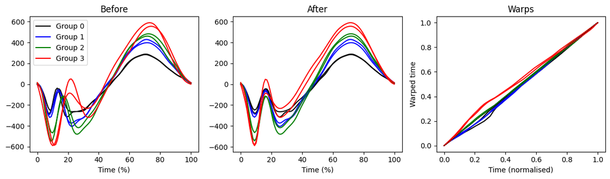

```python
win = result.plot(group=speed, colors=colors, backend='pyqtgraph')      # GraphicsLayoutWidget, 3 PlotItems
plotqt.to_image(win, 'pg_registration.png', size=(1200, 360))
display(Image('pg_registration.png'))

fig, AX = result.plot(group=speed, colors=colors)                        # Matplotlib, for comparison
plt.show()
```

### 2. Individual panels, and drawing into caller-owned widgets

An application typically creates its own layout and hands the plot items to `plotqt`. Below a 2 × 2 `GraphicsLayoutWidget` is filled with raw observations (different lengths), registered observations, warps and displacement fields; the return value of each call is the item passed in.

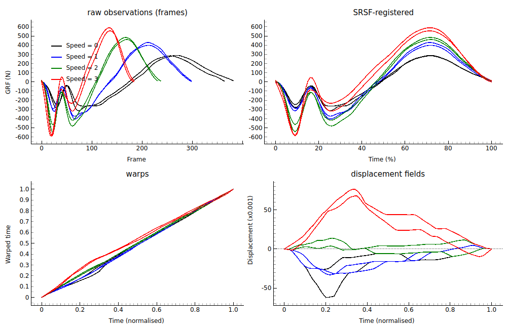

```python
glw = pg.GraphicsLayoutWidget(title='registration1d')
p_raw  = glw.addPlot(title='raw observations (frames)')
p_reg  = glw.addPlot(title='SRSF-registered')
glw.nextRow()
p_warp = glw.addPlot(title='warps')
p_disp = glw.addPlot(title='displacement fields')

plotqt.plot_curves(list(dataset.y), group=speed, plot=p_raw, colors=colors, labels=labels, xlabel='Frame', ylabel='GRF (N)')
plotqt.plot_curves(result.y, group=speed, plot=p_reg, colors=colors, x='percent', legend=False, xlabel='Time (%)')
plotqt.plot_warps(result.warps.asarray(), group=speed, plot=p_warp, colors=colors, legend=False)
plotqt.plot_displacement_fields(result.warps.asarray(), group=speed, plot=p_disp, colors=colors, legend=False)
plotqt.to_image(glw, 'pg_panels.png', size=(1000, 650))
display(Image('pg_panels.png'))
```

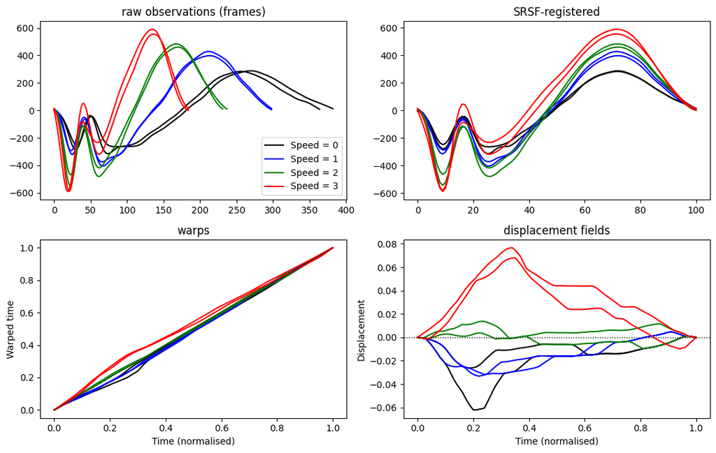

```python
fig, AX = plt.subplots(2, 2, figsize=(11, 7))
reg1d.plot.plot_curves(list(dataset.y), group=speed, ax=AX[0,0], colors=colors, labels=labels); AX[0,0].set_title('raw observations (frames)')
reg1d.plot.plot_curves(result.y, group=speed, ax=AX[0,1], colors=colors, x='percent', legend=False); AX[0,1].set_title('SRSF-registered')
reg1d.plot.plot_warps(result.warps.asarray(), group=speed, ax=AX[1,0], colors=colors, legend=False); AX[1,0].set_title('warps')
reg1d.plot.plot_displacement_fields(result.warps.asarray(), group=speed, ax=AX[1,1], colors=colors, legend=False); AX[1,1].set_title('displacement fields')
plt.tight_layout(); plt.show()
```

### 3. Themes

Stand-alone widgets use a white background with black foreground (`plotqt.set_theme('light')`, applied automatically) so that the default Matplotlib colours (black for the first group) remain visible. `set_theme('dark')` gives PyQtGraph's native look; `set_theme('app')` leaves PyQtGraph's global options untouched for applications that manage their own theme.

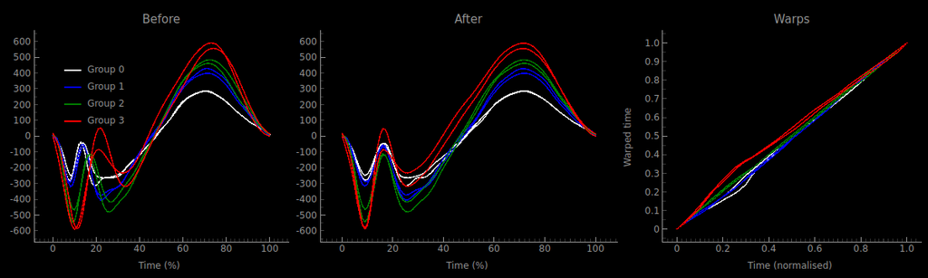

```python
plotqt.set_theme('dark')
win_dark = plotqt.plot_registration(result, group=speed, colors=['w','b','g','r'])
plotqt.to_image(win_dark, 'pg_dark.png', size=(1200, 360))
display(Image('pg_dark.png'))
plotqt.set_theme('light')
```

### 4. Interactive use

In a script or application the same objects are shown as live windows:

```
win = result.plot(group=speed, backend='pyqtgraph')
win.show()
plotqt.app().exec()
```

The linked axes of the *Before* / *After* panels pan and zoom together, and PyQtGraph's context menu (right click) offers export to PNG / SVG / CSV, which is the route to publication figures from within an application.

```python
for f in ('pg_registration.png', 'pg_panels.png', 'pg_dark.png'):
    os.remove(f)                       # the images are embedded in the notebook outputs
```